# Exam 2

Read [how we grade problem sets and exams](https://www.davidkane.info/post/2019-08-31-problem-sets-and-exams/).

**Objectives for this exam:**

- Students will demonstrate their fluency in data wrangling
- Students will demonstrate a basic ability to write functions and use map_* functions and list columns
- Students will demonstrate their understanding of basic concepts in statistical sampling and inference

Install and load the `Ecdat` package, and load its dataset “HI”, which includes a cross-sectional sample of families from 1993. This data is from Craig Olson’s (1998) paper in the Journal of Applied Econometrics, which surveyed male respondents about whether or not their wives had health insurance, and how many hours a week their wives worked. You can ignore the `weight` parameter for all of these problems.

### Question 1

### 1A)

X percent of men in the sample are married to women who are **neither** covered by their husband’s insurance (hhi) **nor** have health insurance from their own work (whi). Format your answer as a percent with 2 decimal points (ie, 99.99 percent).

### 1B)

Set the seed to 1. Subset the data to black men. We can consider our income data as a single, representative sample of the broader population, which in this case is married black men.

- The variable `Husby` refers to income. Calculate the 90% confidence interval for the mean income, using the percentile method and 1,000 bootstrapped samples. For the bootstramped resampling, draw 1,000 samples with size = 1241 (the number of black respondents) and replace = TRUE. Present your result multiplying by 1000, the units for income.

The upper bound of this confidence interval is X and the lower bound of this interval is X

### 1C)

In one paragraph (max words = 100):

- Interpret this confidence interval.
- Explain the difference between the “Bayesian” and “frequentist” interpretation of this confidence interval. You might want to check out the Confidence Intervals section of [PPBDS](https://davidkane9.github.io/PPBDS/10-confidence-intervals.html) for help.

### 1D)

Replicate the plot below, which shows the distribution of hours worked by the respondents’ wives based on the total number of children. Note that you’ll need to use both variables about children - one for children under 6 (kidslt6) and one for children 6-18 (kids618). You might want to create a new variable for categories of kids, using `case_when`. You should set alpha = .4 and use `scale_fill_viridis_d()` and `theme_classic()` to make your plot look like ours. You should make your plot **identical** to ours.

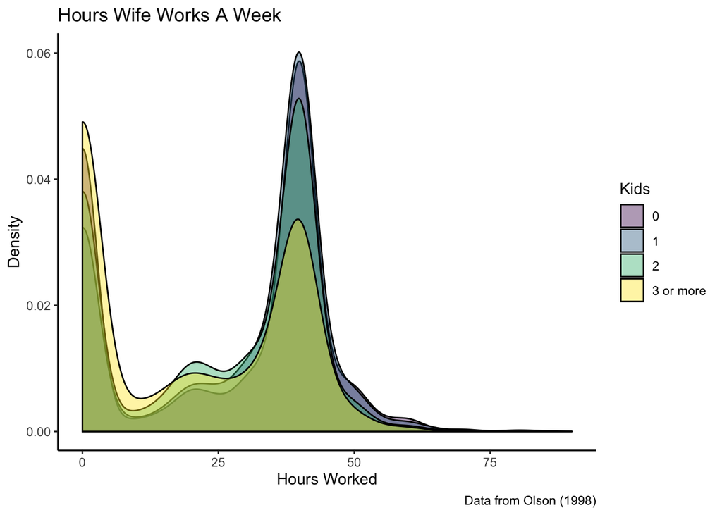

### Question 2

### 2A)

For the remainder of the pset, we’re going to practice sampling by examining Preceptor’s practice of cold-calling.

[figure not shown]

Write a function named `my_cold_call()`. This function has one argument: `file_name`. You should give it, as a default value, “raw-data/students.csv”, which is the path to a file of student names which is located in raw-data directory in your repo for the exam.

`my_cold_call()` does several things. First, it should randomly select a number from 1:7. This is the number of students preceptor will cold-call in class on a given day. Second, it should read the csv based on the path specified in `file_name`. You might want to specify that the columns should be characters. Third, it should draw the sampled number of names from the “name” column in the csv. Finally, it returns these names as a character vector. Set `replace = TRUE` since Preceptor sometimes calls in the same student more than once.

Run your `my_cold_call()` function, with `echo=TRUE` in your code chunk. It should look something like this:

```r
set.seed(10)
my_cold_call()
```

```
## [1] "Cassidy Bargell" "Emily Ni"        "Kelsey Wu"
```

The exact names, and number of names, returned by your function might be different from ours. And that is OK! We use `set.seed()` so that we get the same answer each time in creating the exam. You do not need to use `set.seed()`, although you may find it useful to use as you are working on your code.

### 2B

Using your `my_cold_call()` function, create a tibble called `days` with 36 class days. Your tibble should have 36 rows and 2 columns: a “day” column numbered 1:36 and a list column called “students” with a list of the students drawn each day. Notice that if you’ve written your function correctly, the length of the list will vary by entry. Print a table, using **gt**, of the first 4 rows of your tibble. It should look something like this:

Cold Calls

First Four Days of Class

| Day | Students |
| --- | --- |
| 1 | Yong Lee, Jenna Moustafa, Haeyun Lee, Belinda Hu |
| 2 | Rachel Phan, Garrett Rolph, Matej Cerman, Matej Cerman, Wyatt Hurt, John Morse, Emily Ni |
| 3 | Diassa Diakite, Chase Bookin |
| 4 | Henry Austin, Micah Williams, Rachel Auslander, Naina Tejani, Daniela Teran, Makenna Famulari, Cameron Reaves |

The values in your table may be different, especially if you write the function in a different way. And that is OK!

### 2C

Using your tibble, calculate the percent of days that Eliot Min, Rachel Auslender, **OR** Makenna Famulari’s name is called. What percent of days does your algorithm call at least one of those students? Format your result as a percent with 2 decimal points (ie, 99.99%) (Again, this answer will vary based on your tibble.)

There are multiple ways to do this:

- You can use `map_lgl()` create one column each for Eliot Min, Rachel Auslander, and Makenna Famulari, reporting TRUE if the student’s name is called, and then use another map_lgl() phrase to check whether any of the values is TRUE.
- You can skip this step, and use an “any” expression to check whether any of the three names in the list is called.
- You can use another approach (the two above are just suggestions).